# Pulse train spectrum

W. Bauer

05/25/2015

Photoacoustic excitation might consist of a periodic sequence of NIR pulses. The purpose of this note is to estimate the proportion of a pulse train’s power spectrum which might be accessible to off-the-shelf ultrasound transducers, say the portion between 1 and 10 MHz.

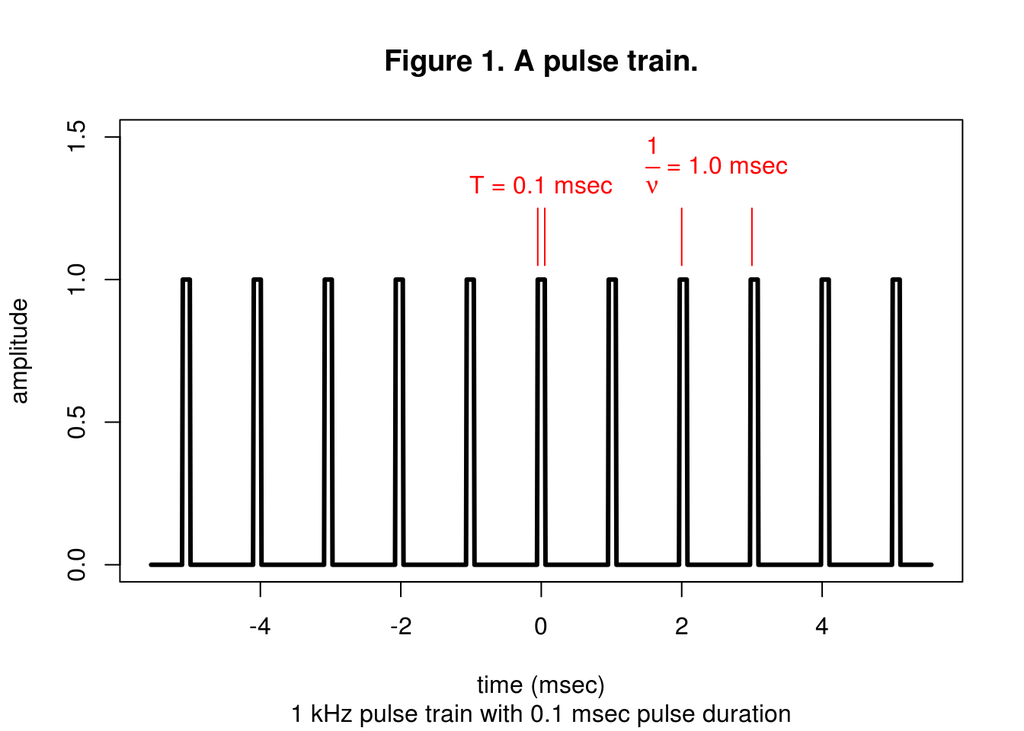

A stylized pulse train of unit amplitude with a repetition rate of $\nu$ and a pulse duration of $T$ has the Fourier series,$2 \nu T\sum_{k=0}^{\infty}\frac{sin(k\pi\nu T)}{k\pi\nu T}cos(2k\pi\nu t).$(See below for details.)

Since millisecond time resolution is desired, pulse repetition rates should be at lease 1 kHz, but probably no more than 1 MHz considering the 1-10 MHz frequency range of interest. Corresponding periods will thus be in the microsecond to millisecond range. Pulse durations and VSD relaxation times will be much shorter (nanoseconds.)

Thus, short stylized pulses of unit amplitude are a rough model of acoustic response to pulsed excitation. The energy produced in one period of such a pulse train is the area under a pulse, namely $T$. The proportion of that energy in one period of the $k^{th}$ Fourier component is$\frac{1}{T}(2\nu T)^2 \left[\frac{sin(k\pi\nu T)}{k\pi\nu T}\right]^2\int_0^{1/\nu}cos^2(2k\pi\nu t)dt \\ = 2\nu T \left[\frac{sin(k\pi\nu T)}{k\pi\nu T}\right]^2$since$\int_0^{1/\nu}cos^2(2k\pi\nu t)dt = \frac{1}{2\nu}.$

For a pulse duration of approximately 10 nanoseconds and $k\nu$ less than 10 MHz, the squared Fourier coefficents are approximately 1. E.g., if $k\nu = 10^7$ (10 MHz), then$\left[\frac{sin(k\pi\nu T)}{k\pi\nu T}\right]^2 = \left[\frac{sin(\pi\times 10^7 \times 10^{-8})}{\pi\times 10^7 \times 10^{-8}}\right]^2 \\ = 0.97.$Hence the fraction of response power within a frequency interval, $[f_1,\:f_2],$ is essentially proportional to the number of Fourier components in that interval, i.e.,$2\nu T\frac{f_2-f_1}{\nu} = 2 T (f_2-f_1).$

For $T \approx 10\:nsec$ this amounts to only 2% of the response power per megahertz of bandwidth.

### Fourier coefficients of a pulse train

A pulse train as pictured in Figure 1 has a Fourier series in which the sine terms are all zero, as is the case for any function for which $f(-t) = f(t).$ The $k^{th}$ Fourier coefficient is, by definition,$a_k = 2\nu\int_{-T/2}^{T/2}cos(2\pi k \nu t)dt \\= 2\nu \frac{sin(2\pi k \nu t)}{2 \pi k \nu}|_{-T/2}^{\:T/2} \\= 2 \nu T \frac{sin(\pi k \nu T)}{\pi k \nu T}.$